# Solow Growth Model (Part 1) — Reproducible Econometrics

Davide Yang

## Research question

This report tests the qualitative Solow-style predictions using World Bank data:

- Higher savings (investment) should be associated with higher GDP per capita.
- Higher population-growth term should be associated with lower GDP per capita.

**Model (Part 1):**

$$\log(y_{it}) = \alpha + \beta_1 \log(s_{it}) + \beta_2 \log(n_{it} + g +
\delta) + \varepsilon_{it}$$

where we set $g+\delta = 0.05$. This avoids dropping observations simply because population growth is negative.

## Data and sample

- Source: World Bank (downloadable automatically via script).
- Sample window: 1982–2019.
- Extremely sparse countries are excluded (high missingness in key variables).

Missing values are handled using **multiple imputation (mice)**. Results are compared to a **complete-case** regression with **HC3 robust standard errors**.

## Results

### Main (Multiple Imputation pooled)

Main regression (MI pooled). Log-log coefficients can be read as elasticities.

| term | estimate | std_error | statistic | df | p_value | ci_low | ci_high |
| --- | --- | --- | --- | --- | --- | --- | --- |
| (Intercept) | 3.968 | 0.701 | 5.664 | 21.668 | <0.001 | 2.514 | 5.422 |
| log_s | 0.385 | 0.116 | 3.319 | 17.200 | 0.004 | 0.141 | 0.630 |
| log_ngd | -1.764 | 0.197 | -8.960 | 24.675 | <0.001 | -2.170 | -1.358 |

**Interpretation (elasticities):**

```
## - `log_s` is positive: a 1% increase in savings is associated with about 0.385% higher GDP per capita (holding the population-growth term fixed).
## - `log_ngd` is negative: a 1% increase in (n+g+δ) is associated with about -1.764% lower GDP per capita (holding savings fixed).
```

Because this is a pooled specification, these should be treated as **associations** (so not actual causal effects).

### Robustness (Complete-case + HC3)

Robustness: complete-case OLS with HC3 robust standard errors.

| term | estimate | std_error | statistic | p_value |
| --- | --- | --- | --- | --- |
| (Intercept) | 4.425 | 0.363 | 12.206 | <0.001 |
| log_s | 0.438 | 0.012 | 35.961 | <0.001 |
| log_ngd | -1.677 | 0.130 | -12.861 | <0.001 |

The signs and magnitudes are broadly consistent across MI and complete-case, which supports the stability of our main qualitative conclusion.

## Diagnostics

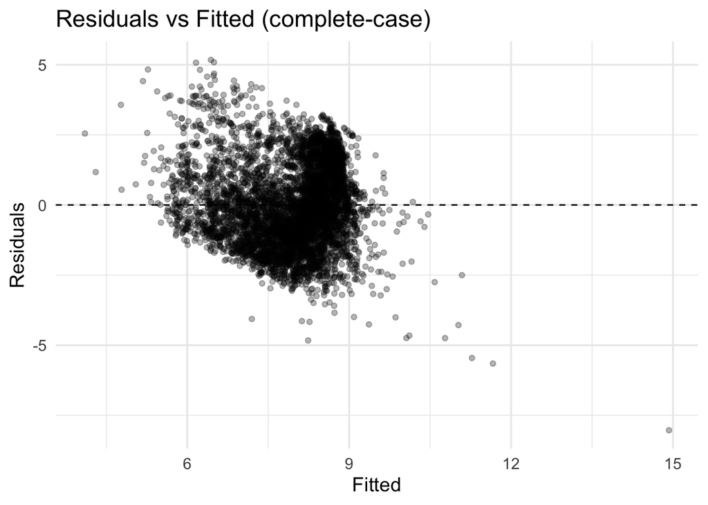

- Residuals are mostly centered around zero.
- Outliers exist (expected in cross-country macro data).
- Heteroskedasticity is plausible → reporting **robust SE** is appropriate (as done above).

## Conclusion (Part 1)

**Main conclusion:** The data support the standard Solow-style qualitative predictions:

- Savings ↗ GDP per capita.
- Population-growth term ↘ GDP per capita.

**what’s done in Part 1:**

- Fully reproducible pipeline (download → clean → impute → estimate → export).
- MI results + complete-case robust-SE check.

## Notes / limitations (what will be in Part 2)

- Panel structure is not yet modeled (country FE / year FE planned).
- Clustered standard errors by country planned.
- More robustness planned (PPP GDPpc outcome, subperiods, winsorization/outlier robustness).